# Statistical Inference Course Project

Bamini Balaji

January 22, 2017

## Part 1: Simulation

### Overview

The objective is to simulate the exponential distribution in R and compare it with the Central Limit Theorem. The exponential distribution can be simulated in R with rexp(n, lambda) where lambda is the rate parameter. The mean of exponential distribution is 1/lambda and the standard deviation is also 1/lambda.

### Simulation Code

Let’s set lambda = 0.2 for all of the simulations.

First, we will simulate 1000 sets of 40 exponentials. Then, we will compute their means and store it in a vector of length 1000 named “means”.

```r
lambda <- 0.2
n = 40 # This indicates number of distributions to be averaged
s = 1000 # This is number of simulations
sim_data <- matrix(rexp(s*n, lambda), nrow = n, ncol = s)
means <- apply(sim_data, 2, mean)
sdev <- apply(sim_data, 2, sd)
avgmeans <- mean(means)
avgsd <- mean(sdev)
```

### Analysis of Mean

The average of ovserved means is 5.0212964.

The theoretical mean of this distribution is 1/lambda or 5.

The following figure shows the observed distribution of means through a histogram. The expected value of the theoretical mean is shown by the red line.

This looks like a normal distribution!

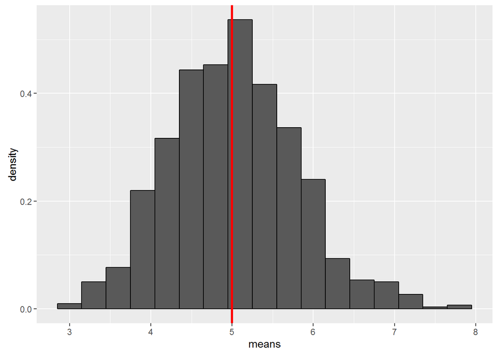

Let’s perform a hypothesis test with alpha of 0.05:

- H_0 : mu = 5.0
- H_a : mu != 5.0

```r
t.test(means, mu = 5, conf.level = 0.95)
```

```
##
##  One Sample t-test
##
## data:  means
## t = 0.85595, df = 999, p-value = 0.3922
## alternative hypothesis: true mean is not equal to 5
## 95 percent confidence interval:
##  4.972473 5.070120
## sample estimates:
## mean of x
##  5.021296
```

Null hypothesis is rejected if p-value is less than 0.05 (alpha).

### Analysis of Variance

The measured average standard deviation equals 4.9168943.

The theoretical standard deviation of an exponential distribution is 1/lambda or 5.

The standard deviation of the observed distribution is theoretically sigma/sqrt(n), or 0.7905694 where n = 40 and sigma is 1/lambda.

Let’s overlay a normal distribution to this figure. Z ~ N(5, 5/sqrt(40))

This distribution is illustrated using the blue curve.

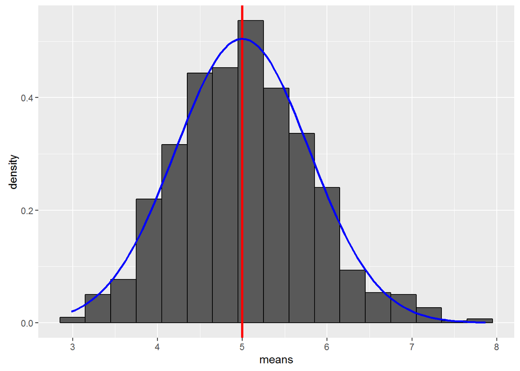

Let’s perform a hypothesis test with alpha of 0.05:

- H_0 : sd = 5.0
- H_a : sd != 5.0

```r
t.test(sdev, mu = 5, conf.level = 0.95)
```

```
##
##  One Sample t-test
##
## data:  sdev
## t = -2.5344, df = 999, p-value = 0.01142
## alternative hypothesis: true mean is not equal to 5
## 95 percent confidence interval:
##  4.852548 4.981241
## sample estimates:
## mean of x
##  4.916894
```

Null hypothesis is rejected if p-value is less than 0.05 (alpha).

## Part 2: Toothgrowth Data Analysis

Let us take a look at the toothgrowth data set:

```r
# These are the first 5 lines of the dataset
head(ToothGrowth)
```

```
##    len supp dose
## 1  4.2   VC  0.5
## 2 11.5   VC  0.5
## 3  7.3   VC  0.5
## 4  5.8   VC  0.5
## 5  6.4   VC  0.5
## 6 10.0   VC  0.5
```

```r
# The dimensions of the data set:
dim(ToothGrowth)
```

```
## [1] 60  3
```

This data shows length of tooth under different doses and different types of supplements for 60 specimen.

```r
summary(ToothGrowth)
```

```
##       len        supp         dose
##  Min.   : 4.20   OJ:30   Min.   :0.500
##  1st Qu.:13.07   VC:30   1st Qu.:0.500
##  Median :19.25           Median :1.000
##  Mean   :18.81           Mean   :1.167
##  3rd Qu.:25.27           3rd Qu.:2.000
##  Max.   :33.90           Max.   :2.000
```

```r
table(ToothGrowth$supp, ToothGrowth$dose)
```

```
##
##      0.5  1  2
##   OJ  10 10 10
##   VC  10 10 10
```

The tooth length ranges from 4.20 to 33.90.

Supplements are either orange juice (OJ) or vitamin C (VC). Dose values are 0.5, 1, 2. For each combination of supplement and dose, 10 subjects are tested.

This figure shows the tooth length (y-axis) versus supplement OJ or VC for the various dose levels.

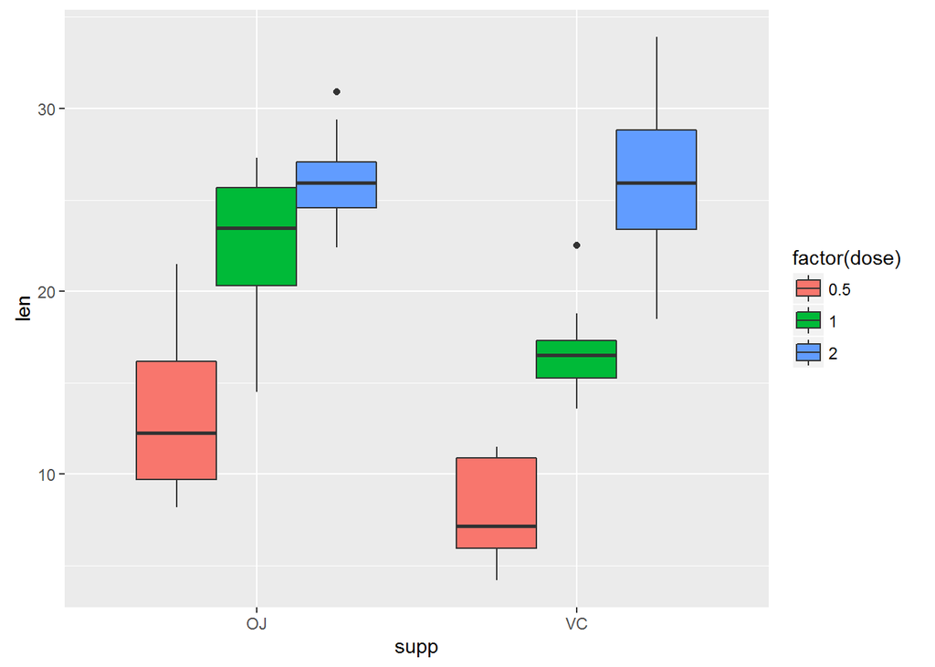

### OJ versus VC

Does orange juice (OJ) stimulate tooth growth over vitamic C (VC)?

```r
with(ToothGrowth, t.test(len[supp == "VC"], len[supp == "OJ"], paired = FALSE, var.equal = FALSE))
```

```
##
##  Welch Two Sample t-test
##
## data:  len[supp == "VC"] and len[supp == "OJ"]
## t = -1.9153, df = 55.309, p-value = 0.06063
## alternative hypothesis: true difference in means is not equal to 0
## 95 percent confidence interval:
##  -7.5710156  0.1710156
## sample estimates:
## mean of x mean of y
##  16.96333  20.66333
```

```r
pval <- with(ToothGrowth, t.test(len[supp == "VC"], len[supp == "OJ"], paired = FALSE, var.equal = FALSE))$p.value
```

p-value > alpha. Hence null hypothesis that VC and OJ are equivalent is accepted

Let’s look at the data for a specific dose level of 0.5

```r
with(ToothGrowth, t.test(len[supp == "VC" & dose == 0.5], len[supp == "OJ" & dose == 0.5], paired = FALSE, var.equal = FALSE))
```

```
##
##  Welch Two Sample t-test
##
## data:  len[supp == "VC" & dose == 0.5] and len[supp == "OJ" & dose == 0.5]
## t = -3.1697, df = 14.969, p-value = 0.006359
## alternative hypothesis: true difference in means is not equal to 0
## 95 percent confidence interval:
##  -8.780943 -1.719057
## sample estimates:
## mean of x mean of y
##      7.98     13.23
```

```r
pval <- c(pval, with(ToothGrowth, t.test(len[supp == "VC" & dose == 0.5], len[supp == "OJ" & dose == 0.5], paired = FALSE, var.equal = FALSE))$p.value)
```

Here p-value < alpha. The confidence interval does not encompass 0. Hence alternative hypothesis is accepted where the OJ and VC have different impact at 0.5 dose. In fact, since the values are negative in confidence interval range, it suggests that OJ > VC for 0.5 dose.

Now, let’s look at dose of 2.

```r
with(ToothGrowth, t.test(len[supp == "VC" & dose == 2], len[supp == "OJ" & dose == 2], paired = FALSE, var.equal = FALSE))
```

```
##
##  Welch Two Sample t-test
##
## data:  len[supp == "VC" & dose == 2] and len[supp == "OJ" & dose == 2]
## t = 0.046136, df = 14.04, p-value = 0.9639
## alternative hypothesis: true difference in means is not equal to 0
## 95 percent confidence interval:
##  -3.63807  3.79807
## sample estimates:
## mean of x mean of y
##     26.14     26.06
```

```r
pval <- c(pval, with(ToothGrowth, t.test(len[supp == "VC" & dose == 2], len[supp == "OJ" & dose == 2], paired = FALSE, var.equal = FALSE))$p.value)
```

In this case the null hypothesis is accepted. This suggests that at high doses, OJ and VC are equivalent.

## Effect of dose level

Let’s compare a dose of 2 and a dose of 1 collectively regardless of supplement type.

```r
with(ToothGrowth, t.test(len[dose == 2], len[dose == 1], paired = FALSE, var.equal = FALSE))
```

```
##
##  Welch Two Sample t-test
##
## data:  len[dose == 2] and len[dose == 1]
## t = 4.9005, df = 37.101, p-value = 1.906e-05
## alternative hypothesis: true difference in means is not equal to 0
## 95 percent confidence interval:
##  3.733519 8.996481
## sample estimates:
## mean of x mean of y
##    26.100    19.735
```

```r
pval <- c(pval, with(ToothGrowth, t.test(len[dose == 2], len[dose == 1], paired = FALSE, var.equal = FALSE))$p.value)
```

The data confirms that our null hypothesis is rejected. Dose level of 2 causes greater tooth length than dose level 1.

What about in the case of OJ at dose levels 2 and 1. These two data appear close.

```r
with(ToothGrowth, t.test(len[supp == "OJ" & dose == 2], len[supp == "OJ" & dose == 1], paired = FALSE, var.equal = FALSE))
```

```
##
##  Welch Two Sample t-test
##
## data:  len[supp == "OJ" & dose == 2] and len[supp == "OJ" & dose == 1]
## t = 2.2478, df = 15.842, p-value = 0.0392
## alternative hypothesis: true difference in means is not equal to 0
## 95 percent confidence interval:
##  0.1885575 6.5314425
## sample estimates:
## mean of x mean of y
##     26.06     22.70
```

```r
pval <- c(pval, with(ToothGrowth, t.test(len[supp == "OJ" & dose == 2], len[supp == "OJ" & dose == 1], paired = FALSE, var.equal = FALSE))$p.value)
```

Overall these tests suggest that dose level has a large impact. At low doses, OJ is more effective than VC. But at high doses this effect does not matter.

However since we have used this data for multiple testing, it would be advisable to avoid false discoveries. This can be done my using the BH correction.

```r
pval
```

```
## [1] 0.0606345079 0.0063586068 0.9638515887 0.0000190643 0.0391951420
```

```r
p.adjust(pval, method = "BH")
```

```
## [1] 7.579313e-02 1.589652e-02 9.638516e-01 9.532148e-05 6.532524e-02
```

The last test comparing tooth length with OJ at dose level 2 versus 1 is no longer showing a significant finding since p-value > alpha. Hence these two conditions would be considered equivalent.